# Bikeshare Space-Time Prediction: Q3 2024

CPLN 5080 Lab 5 — Spring 2026

Author

Muhammad Yusuf Khalil

Published

April 26, 2026

# Introduction

# Set up

```r
library(tidyverse)
library(lubridate)
library(sf)
library(tigris)
library(tidycensus)
library(riem)

library(viridis)
library(knitr)
library(kableExtra)
library(patchwork)

library(here)
options(scipen = 999)
```

```r
plotTheme <- theme_minimal() +
  theme(
    plot.title    = element_text(size = 14, face = "bold"),
    plot.subtitle = element_text(size = 10),
    plot.caption  = element_text(size = 8),
    axis.text.x   = element_text(size = 10, angle = 45, hjust = 1),
    axis.text.y   = element_text(size = 10),
    axis.title    = element_text(size = 11, face = "bold"),
    panel.grid.major = element_line(colour = "#D0D0D0", linewidth = 0.2),
    panel.grid.minor = element_blank(),
    axis.ticks    = element_blank(),
    legend.position = "right"
  )

mapTheme <- theme_void() +
  theme(
    plot.title    = element_text(size = 14, face = "bold"),
    plot.subtitle = element_text(size = 10),
    plot.caption  = element_text(size = 8),
    legend.position  = "right",
    plot.margin      = margin(1, 1, 1, 1, "cm"),
    legend.key.height = unit(1, "cm"),
    legend.key.width  = unit(0.2, "cm")
  )

palette5 <- c("#eff3ff", "#bdd7e7", "#6baed6", "#3182bd", "#08519c")
```

# Import and prep data

## Load Indego trip data (Q3 2024)

```r
indego <- read_csv(here("data/indego-trips-2024-q3.csv"))

glimpse(indego)
```

```
Rows: 408,408
Columns: 15
$ trip_id             <dbl> 953311130, 953308580, 953309085, 953334269, 953334…
$ duration            <dbl> 5, 3, 2, 12, 22, 47, 111, 7, 1, 8, 6, 2, 20, 246, …
$ start_time          <chr> "7/1/2024 0:02", "7/1/2024 0:03", "7/1/2024 0:04",…
$ end_time            <chr> "7/1/2024 0:07", "7/1/2024 0:06", "7/1/2024 0:06",…
$ start_station       <dbl> 3271, 3304, 3052, 3323, 3209, 3101, 3338, 3373, 33…
$ start_lat           <dbl> 39.94760, 39.94234, 39.94732, 40.02796, 39.94900, …
$ start_lon           <dbl> -75.22946, -75.15399, -75.15695, -75.22770, -75.21…
$ end_station         <dbl> 3338, 3028, 3007, 3323, 3344, 3296, 3258, 3201, 33…
$ end_lat             <dbl> 39.95098, 39.94061, 39.94517, 40.02796, 39.95961, …
$ end_lon             <dbl> -75.23035, -75.14958, -75.15993, -75.22770, -75.23…
$ bike_id             <chr> "03439", "11905", "26031", "19971", "20921", "2241…
$ plan_duration       <dbl> 30, 30, 30, 1, 30, 1, 30, 30, 30, 30, 30, 30, 30, …
$ trip_route_category <chr> "One Way", "One Way", "One Way", "Round Trip", "On…
$ passholder_type     <chr> "Indego30", "Indego30", "Indego30", "Day Pass", "I…
$ bike_type           <chr> "standard", "standard", "electric", "electric", "e…
```

## Examine the data structure

```r
cat("Total trips in Q3 2024:", nrow(indego), "\n")
```

```
Total trips in Q3 2024: 408408
```

```r
# Q3 2024 timestamps may parse as either mdy_hm or ymd_hms depending on the
# release. Try both and use whichever doesn't return NAs.
parse_attempt_mdy <- suppressWarnings(mdy_hm(indego$start_time))
parse_attempt_ymd <- suppressWarnings(ymd_hms(indego$start_time))

if (mean(is.na(parse_attempt_mdy)) < 0.05) {
  indego$start_datetime <- parse_attempt_mdy
  indego$end_datetime   <- suppressWarnings(mdy_hm(indego$end_time))
  cat("Parsed timestamps as mdy_hm.\n")
} else {
  indego$start_datetime <- parse_attempt_ymd
  indego$end_datetime   <- suppressWarnings(ymd_hms(indego$end_time))
  cat("Parsed timestamps as ymd_hms.\n")
}
```

```
Parsed timestamps as mdy_hm.
```

```r
cat("Date range:",
    as.character(min(indego$start_datetime, na.rm = TRUE)), "to",
    as.character(max(indego$start_datetime, na.rm = TRUE)), "\n")
```

```
Date range: 2024-07-01 00:02:00 to 2024-09-30 23:59:00
```

```r
cat("Unique start stations:", length(unique(indego$start_station)), "\n")
```

```
Unique start stations: 261
```

```r
table(indego$trip_route_category)
```

```
   One Way Round Trip
    380939      27469
```

```r
table(indego$passholder_type)
```

```
 Day Pass  Indego30 Indego365   Walk-up
    22885    239857    132358     13308
```

```r
table(indego$bike_type)
```

```
electric standard
  236839   171569
```

## Create time bins

```r
indego <- indego %>%
  mutate(
    interval60 = floor_date(start_datetime, unit = "hour"),
    week       = week(interval60),
    month      = month(interval60, label = TRUE),
    dotw       = wday(interval60, label = TRUE),
    hour       = hour(interval60),
    date       = as.Date(interval60),
    weekend    = ifelse(dotw %in% c("Sat", "Sun"), 1, 0),
    rush_hour  = ifelse(hour %in% c(7, 8, 9, 16, 17, 18), 1, 0)
  ) %>%
  filter(!is.na(interval60))

head(indego %>% select(start_datetime, interval60, week, dotw, hour, weekend))
```

```
# A tibble: 6 × 6
  start_datetime      interval60           week dotw   hour weekend
  <dttm>              <dttm>              <dbl> <ord> <int>   <dbl>
1 2024-07-01 00:02:00 2024-07-01 00:00:00    27 Mon       0       0
2 2024-07-01 00:03:00 2024-07-01 00:00:00    27 Mon       0       0
3 2024-07-01 00:04:00 2024-07-01 00:00:00    27 Mon       0       0
4 2024-07-01 00:05:00 2024-07-01 00:00:00    27 Mon       0       0
5 2024-07-01 00:06:00 2024-07-01 00:00:00    27 Mon       0       0
6 2024-07-01 00:06:00 2024-07-01 00:00:00    27 Mon       0       0
```

# EDA of Indego data

## Trips over time

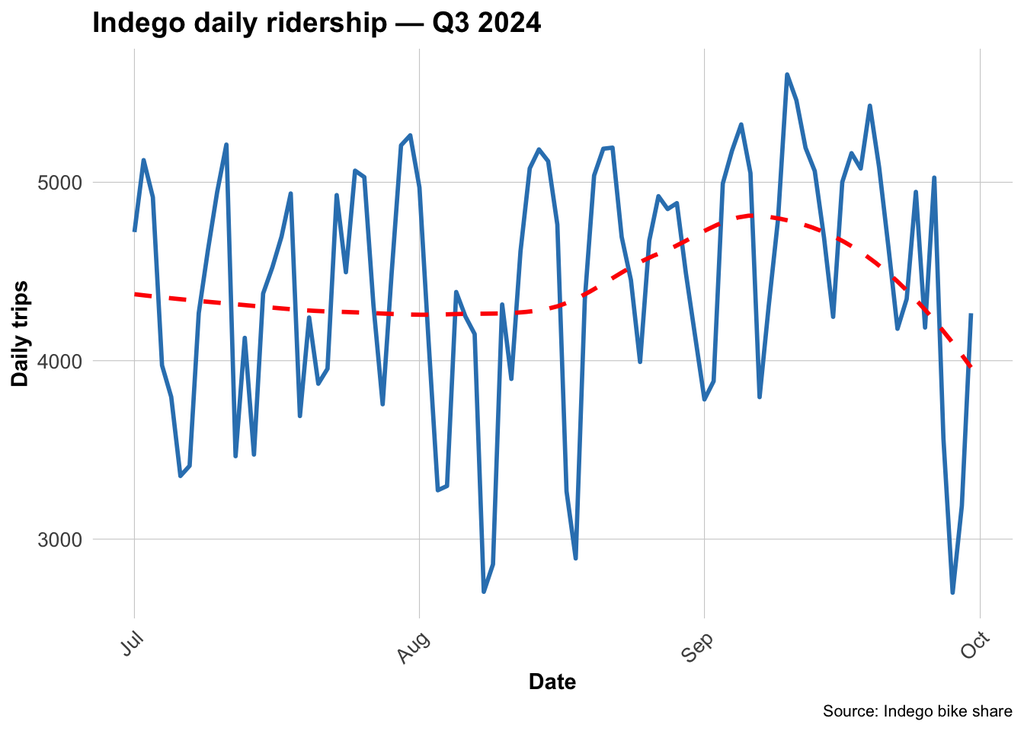

```r
daily_trips <- indego %>%
  group_by(date) %>%
  summarize(trips = n())

ggplot(daily_trips, aes(x = date, y = trips)) +
  geom_line(color = "#3182bd", linewidth = 1) +
  geom_smooth(se = FALSE, color = "red", linetype = "dashed") +
  labs(
    title = "Indego daily ridership — Q3 2024",
    x = "Date",
    y = "Daily trips",
    caption = "Source: Indego bike share"
  ) +
  plotTheme
```

## Hourly patterns

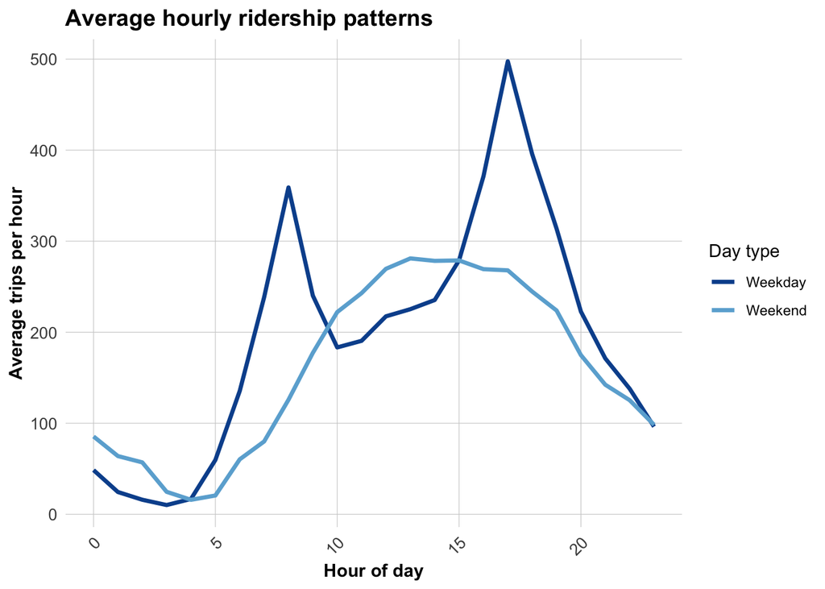

```r
hourly_patterns <- indego %>%
  group_by(hour, weekend) %>%
  summarize(avg_trips = n() / n_distinct(date), .groups = "drop") %>%
  mutate(day_type = ifelse(weekend == 1, "Weekend", "Weekday"))

ggplot(hourly_patterns, aes(x = hour, y = avg_trips, color = day_type)) +
  geom_line(linewidth = 1.2) +
  scale_color_manual(values = c("Weekday" = "#08519c", "Weekend" = "#6baed6")) +
  labs(
    title = "Average hourly ridership patterns",
    x = "Hour of day",
    y = "Average trips per hour",
    color = "Day type"
  ) +
  plotTheme
```

Weekdays show the standard twin-peaked commute profile. Weekends are unimodal, shifted later to leisure ridership.

## Top stations

```r
top_stations <- indego %>%
  count(start_station, start_lat, start_lon, name = "trips") %>%
  arrange(desc(trips)) %>%
  head(20)

kable(top_stations,
      caption = "Top 20 Indego stations by trip origins (Q3 2024)",
      format.args = list(big.mark = ",")) %>%
  kable_styling(bootstrap_options = c("striped", "hover"))
```

Top 20 Indego stations by trip origins (Q3 2024)

| start_station | start_lat | start_lon | trips |
| --- | --- | --- | --- |
| 3,010 | 39.94711 | -75.16618 | 6,654 |
| 3,032 | 39.94527 | -75.17971 | 5,436 |
| 3,244 | 39.93865 | -75.16674 | 4,421 |
| 3,054 | 39.96250 | -75.17420 | 4,305 |
| 3,359 | 39.94888 | -75.16978 | 4,305 |
| 3,296 | 39.95134 | -75.16758 | 4,252 |
| 3,101 | 39.94295 | -75.15955 | 4,226 |
| 3,020 | 39.94855 | -75.19007 | 4,154 |
| 3,295 | 39.95028 | -75.16027 | 4,144 |
| 3,066 | 39.94561 | -75.17348 | 4,114 |
| 3,059 | 39.96244 | -75.16121 | 4,022 |
| 3,022 | 39.95472 | -75.18323 | 3,954 |
| 3,362 | 39.94816 | -75.16226 | 3,948 |
| 3,163 | 39.94974 | -75.18097 | 3,942 |
| 3,028 | 39.94061 | -75.14958 | 3,921 |
| 3,208 | 39.95048 | -75.19324 | 3,919 |
| 3,061 | 39.95425 | -75.17761 | 3,796 |
| 3,046 | 39.95012 | -75.14472 | 3,734 |
| 3,063 | 39.94633 | -75.16980 | 3,726 |
| 3,185 | 39.95169 | -75.15888 | 3,678 |

# Put data in context

## Load Philadelphia census data

```r
philly_census <- get_acs(
  geography = "tract",
  variables = c(
    "B01003_001",  # Total population
    "B19013_001",  # Median household income
    "B08301_001",  # Total commuters
    "B08301_010",  # Commute by transit
    "B02001_002",  # White alone
    "B25077_001"   # Median home value
  ),
  state = "PA",
  county = "Philadelphia",
  year = 2022,
  geometry = TRUE,
  output = "wide"
) %>%
  rename(
    Total_Pop          = B01003_001E,
    Med_Inc            = B19013_001E,
    Total_Commuters    = B08301_001E,
    Transit_Commuters  = B08301_010E,
    White_Pop          = B02001_002E,
    Med_Home_Value     = B25077_001E
  ) %>%
  mutate(
    Percent_Taking_Transit = (Transit_Commuters / Total_Commuters) * 100,
    Percent_White          = (White_Pop / Total_Pop) * 100
  ) %>%
  st_transform(crs = 4326)
```

## Map context with stations

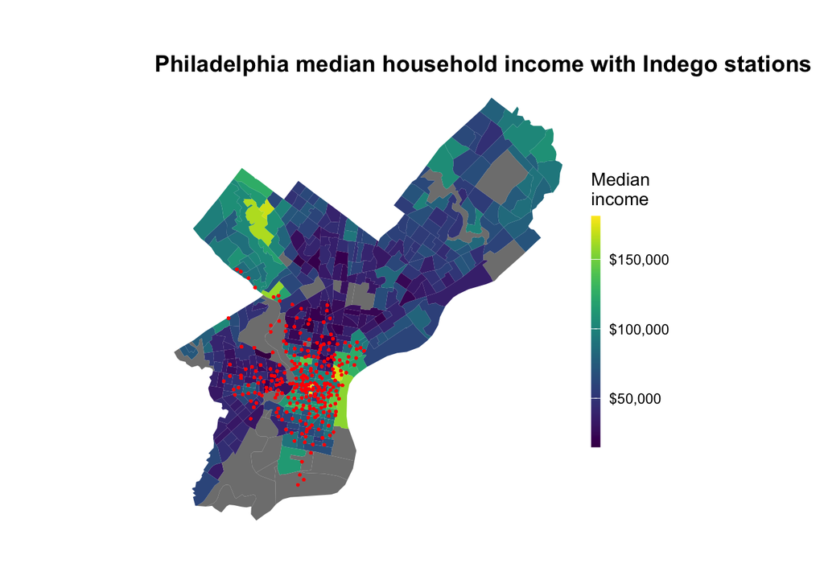

```r
ggplot() +
  geom_sf(data = philly_census, aes(fill = Med_Inc), color = NA) +
  scale_fill_viridis(option = "viridis", name = "Median\nincome",
                     labels = scales::dollar) +
  geom_point(data = indego,
             aes(x = start_lon, y = start_lat),
             color = "red", size = 0.25, alpha = 0.6) +
  labs(title = "Philadelphia median household income with Indego stations") +
  mapTheme
```

## Spatial join — stations to tracts

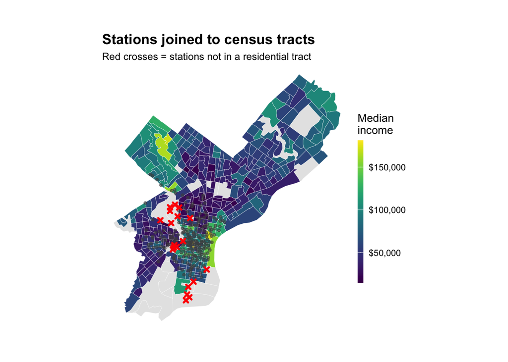

```r
stations_sf <- indego %>%
  distinct(start_station, start_lat, start_lon) %>%
  filter(!is.na(start_lat), !is.na(start_lon)) %>%
  st_as_sf(coords = c("start_lon", "start_lat"), crs = 4326)

stations_census <- st_join(stations_sf, philly_census, left = TRUE) %>%
  st_drop_geometry()

stations_for_map <- indego %>%
  distinct(start_station, start_lat, start_lon) %>%
  filter(!is.na(start_lat), !is.na(start_lon)) %>%
  left_join(stations_census %>% select(start_station, Med_Inc),
            by = "start_station") %>%
  mutate(has_census = !is.na(Med_Inc))

ggplot() +
  geom_sf(data = philly_census, aes(fill = Med_Inc),
          color = "white", size = 0.1) +
  scale_fill_viridis(option = "viridis", name = "Median\nincome",
                     labels = scales::dollar, na.value = "grey90") +
  geom_point(data = stations_for_map %>% filter(has_census),
             aes(x = start_lon, y = start_lat),
             color = "grey30", size = 1, alpha = 0.6) +
  geom_point(data = stations_for_map %>% filter(!has_census),
             aes(x = start_lon, y = start_lat),
             color = "red", size = 1, shape = 4, stroke = 1.5) +
  labs(title = "Stations joined to census tracts",
       subtitle = "Red crosses = stations not in a residential tract") +
  mapTheme
```

## Drop non-residential stations

Following the in-class approach, I drop stations that don’t sit inside a residential tract.

```r
valid_stations <- stations_census %>%
  filter(!is.na(Med_Inc)) %>%
  pull(start_station)

indego_census <- indego %>%
  filter(start_station %in% valid_stations) %>%
  left_join(
    stations_census %>%
      select(start_station, Med_Inc, Percent_Taking_Transit,
             Percent_White, Total_Pop),
    by = "start_station"
  )
```

## Weather (KPHL, Q3 2024)

```r
weather_data <- riem_measures(
  station    = "PHL",
  date_start = "2024-07-01",
  date_end   = "2024-09-30"
)

weather_processed <- weather_data %>%
  mutate(
    interval60    = floor_date(valid, unit = "hour"),
    Temperature   = tmpf,
    Precipitation = ifelse(is.na(p01i), 0, p01i),
    Wind_Speed    = sknt
  ) %>%
  select(interval60, Temperature, Precipitation, Wind_Speed) %>%
  distinct(interval60, .keep_all = TRUE)

weather_complete <- weather_processed %>%
  complete(interval60 = seq(min(interval60), max(interval60), by = "hour")) %>%
  fill(Temperature, Precipitation, Wind_Speed, .direction = "down")

summary(weather_complete %>% select(Temperature, Precipitation, Wind_Speed))
```

```
  Temperature    Precipitation         Wind_Speed
 Min.   :55.00   Min.   :0.0000000   Min.   : 0.000
 1st Qu.:70.00   1st Qu.:0.0000000   1st Qu.: 4.000
 Median :76.00   Median :0.0000000   Median : 7.000
 Mean   :75.97   Mean   :0.0007436   Mean   : 6.656
 3rd Qu.:81.00   3rd Qu.:0.0000000   3rd Qu.: 9.000
 Max.   :98.00   Max.   :0.2200000   Max.   :27.000
```

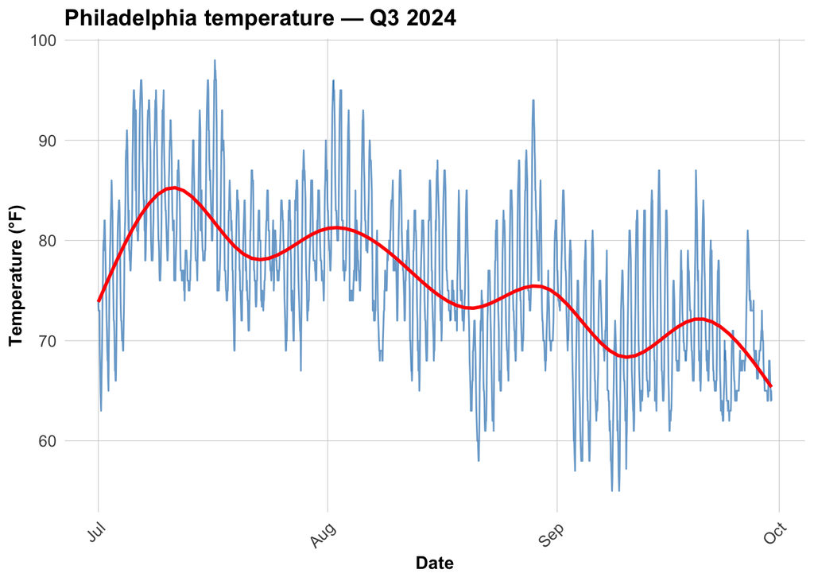

```r
ggplot(weather_complete, aes(x = interval60, y = Temperature)) +
  geom_line(color = "#3182bd", alpha = 0.7) +
  geom_smooth(se = FALSE, color = "red") +
  labs(title = "Philadelphia temperature — Q3 2024",
       x = "Date", y = "Temperature (°F)") +
  plotTheme
```

# Build the space-time panel

## Aggregate trips to station-hour

```r
trips_panel <- indego_census %>%
  group_by(interval60, start_station, start_lat, start_lon,
           Med_Inc, Percent_Taking_Transit, Percent_White, Total_Pop) %>%
  summarize(Trip_Count = n(), .groups = "drop")

cat("Station-hour rows with at least one trip:",
    format(nrow(trips_panel), big.mark = ","), "\n")
```

```
Station-hour rows with at least one trip: 193,072
```

```r
cat("Unique stations:", length(unique(trips_panel$start_station)), "\n")
```

```
Unique stations: 241
```

```r
cat("Unique hours:",    length(unique(trips_panel$interval60)),     "\n")
```

```
Unique hours: 2202
```

## Complete the panel

```r
n_stations    <- length(unique(trips_panel$start_station))
n_hours       <- length(unique(trips_panel$interval60))
expected_rows <- n_stations * n_hours

cat("Expected panel rows:", format(expected_rows, big.mark = ","), "\n")
```

```
Expected panel rows: 530,682
```

```r
study_panel <- expand_grid(
  interval60    = unique(trips_panel$interval60),
  start_station = unique(trips_panel$start_station)
) %>%
  left_join(trips_panel %>%
              select(interval60, start_station, Trip_Count),
            by = c("interval60", "start_station")) %>%
  mutate(Trip_Count = replace_na(Trip_Count, 0))

station_attributes <- trips_panel %>%
  group_by(start_station) %>%
  summarize(
    start_lat              = first(start_lat),
    start_lon              = first(start_lon),
    Med_Inc                = first(Med_Inc),
    Percent_Taking_Transit = first(Percent_Taking_Transit),
    Percent_White          = first(Percent_White),
    Total_Pop              = first(Total_Pop),
    .groups                = "drop"
  )

study_panel <- study_panel %>%
  left_join(station_attributes, by = "start_station")

cat("Complete panel rows:", format(nrow(study_panel), big.mark = ","), "\n")
```

```
Complete panel rows: 530,682
```

## Time features

```r
study_panel <- study_panel %>%
  mutate(
    week      = week(interval60),
    month     = month(interval60, label = TRUE),
    dotw      = wday(interval60, label = TRUE),
    hour      = hour(interval60),
    date      = as.Date(interval60),
    weekend   = ifelse(dotw %in% c("Sat", "Sun"), 1, 0),
    rush_hour = ifelse(hour %in% c(7, 8, 9, 16, 17, 18), 1, 0)
  )
```

## Join weather

```r
study_panel <- study_panel %>%
  left_join(weather_complete, by = "interval60")

summary(study_panel %>% select(Trip_Count, Temperature, Precipitation))
```

```
   Trip_Count      Temperature    Precipitation
 Min.   : 0.000   Min.   :55.00   Min.   :0.0000
 1st Qu.: 0.000   1st Qu.:70.00   1st Qu.:0.0000
 Median : 0.000   Median :76.00   Median :0.0000
 Mean   : 0.724   Mean   :75.97   Mean   :0.0007
 3rd Qu.: 1.000   3rd Qu.:81.00   3rd Qu.:0.0000
 Max.   :24.000   Max.   :98.00   Max.   :0.2200
                  NA's   :5784    NA's   :5784
```

# Temporal lag variables

```r
study_panel <- study_panel %>%
  arrange(start_station, interval60) %>%
  group_by(start_station) %>%
  mutate(
    lag1Hour   = lag(Trip_Count, 1),
    lag2Hours  = lag(Trip_Count, 2),
    lag3Hours  = lag(Trip_Count, 3),
    lag12Hours = lag(Trip_Count, 12),
    lag1day    = lag(Trip_Count, 24)
  ) %>%
  ungroup()

study_panel_complete <- study_panel %>%
  filter(!is.na(lag1day))

cat("Rows after dropping initial 24h with no lag:",
    format(nrow(study_panel_complete), big.mark = ","), "\n")
```

```
Rows after dropping initial 24h with no lag: 524,898
```

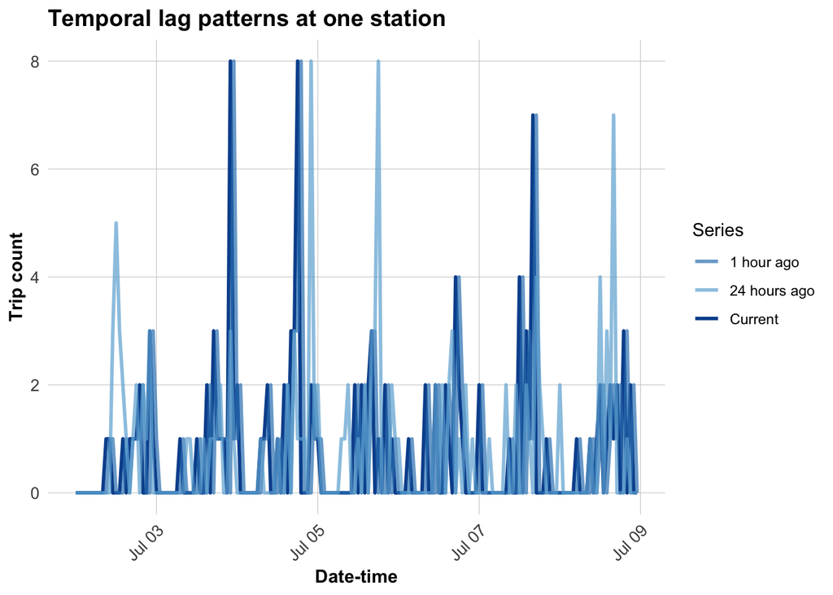

```r
example_station <- study_panel_complete %>%
  filter(start_station == first(start_station)) %>%
  head(168)

ggplot(example_station, aes(x = interval60)) +
  geom_line(aes(y = Trip_Count, color = "Current"), linewidth = 1) +
  geom_line(aes(y = lag1Hour, color = "1 hour ago"), linewidth = 1, alpha = 0.7) +
  geom_line(aes(y = lag1day, color = "24 hours ago"), linewidth = 1, alpha = 0.7) +
  scale_color_manual(values = c("Current" = "#08519c",
                                "1 hour ago" = "#3182bd",
                                "24 hours ago" = "#6baed6")) +
  labs(title = "Temporal lag patterns at one station",
       x = "Date-time", y = "Trip count", color = "Series") +
  plotTheme
```

# Temporal train/test split

Train on the past, test on the future. Q3 spans roughly weeks 27 to 39. I split at the 2/3 point of the quarter to train on the first two-thirds, test on the last third.

```r
cutoff_week <- quantile(study_panel_complete$week, probs = 2/3) %>% floor()
cat("Train weeks: <", cutoff_week, " | Test weeks: >=", cutoff_week, "\n")
```

```
Train weeks: < 35  | Test weeks: >= 35
```

```r
early_stations <- study_panel_complete %>%
  filter(week <  cutoff_week, Trip_Count > 0) %>%
  distinct(start_station) %>% pull(start_station)

late_stations  <- study_panel_complete %>%
  filter(week >= cutoff_week, Trip_Count > 0) %>%
  distinct(start_station) %>% pull(start_station)

common_stations <- intersect(early_stations, late_stations)

study_panel_complete <- study_panel_complete %>%
  filter(start_station %in% common_stations)

train <- study_panel_complete %>% filter(week <  cutoff_week)
test  <- study_panel_complete %>% filter(week >= cutoff_week)

cat("Training observations:", format(nrow(train), big.mark = ","), "\n")
```

```
Training observations: 308,790
```

```r
cat("Testing observations:",  format(nrow(test),  big.mark = ","), "\n")
```

```
Testing observations: 203,040
```

```r
cat("Training date range:", as.character(min(train$date)), "to",
                              as.character(max(train$date)), "\n")
```

```
Training date range: 2024-07-02 to 2024-08-25
```

```r
cat("Testing date range:",  as.character(min(test$date)),  "to",
                              as.character(max(test$date)),  "\n")
```

```
Testing date range: 2024-08-26 to 2024-09-30
```

# Build five baseline models

```r
train <- train %>%
  mutate(dotw_simple = factor(dotw,
                              levels = c("Mon","Tue","Wed","Thu","Fri","Sat","Sun")))
contrasts(train$dotw_simple) <- contr.treatment(7)

test  <- test %>%
  mutate(dotw_simple = factor(dotw,
                              levels = c("Mon","Tue","Wed","Thu","Fri","Sat","Sun")))
contrasts(test$dotw_simple) <- contr.treatment(7)
```

## Model 1: time + weather

```r
model1 <- lm(
  Trip_Count ~ as.factor(hour) + dotw_simple + Temperature + Precipitation,
  data = train
)
cat("Model 1  R²:", summary(model1)$r.squared,
    " Adj R²:", summary(model1)$adj.r.squared, "\n")
```

```
Model 1  R²: 0.1096996  Adj R²: 0.1096102
```

```r
summary(model1)
```

```
Call:
lm(formula = Trip_Count ~ as.factor(hour) + dotw_simple + Temperature +
    Precipitation, data = train)

Residuals:
    Min      1Q  Median      3Q     Max
-1.7204 -0.7896 -0.1977  0.1899 23.4127

Coefficients:
                    Estimate Std. Error t value             Pr(>|t|)
(Intercept)        0.3766015  0.0357564  10.532 < 0.0000000000000002 ***
as.factor(hour)1  -0.1025651  0.0152821  -6.711   0.0000000000193011 ***
as.factor(hour)2  -0.1348832  0.0153872  -8.766 < 0.0000000000000002 ***
as.factor(hour)3  -0.1884618  0.0154237 -12.219 < 0.0000000000000002 ***
as.factor(hour)4  -0.1753249  0.0154624 -11.339 < 0.0000000000000002 ***
as.factor(hour)5  -0.0445832  0.0154955  -2.877              0.00401 **
as.factor(hour)6   0.2212018  0.0155619  14.214 < 0.0000000000000002 ***
as.factor(hour)7   0.5015575  0.0155648  32.224 < 0.0000000000000002 ***
as.factor(hour)8   0.8910438  0.0155487  57.307 < 0.0000000000000002 ***
as.factor(hour)9   0.6471788  0.0155753  41.552 < 0.0000000000000002 ***
as.factor(hour)10  0.5372252  0.0155262  34.601 < 0.0000000000000002 ***
as.factor(hour)11  0.5644966  0.0154279  36.589 < 0.0000000000000002 ***
as.factor(hour)12  0.6732691  0.0153222  43.941 < 0.0000000000000002 ***
as.factor(hour)13  0.6974051  0.0152729  45.663 < 0.0000000000000002 ***
as.factor(hour)14  0.7372334  0.0152745  48.265 < 0.0000000000000002 ***
as.factor(hour)15  0.8185543  0.0153099  53.466 < 0.0000000000000002 ***
as.factor(hour)16  1.0123865  0.0153607  65.908 < 0.0000000000000002 ***
as.factor(hour)17  1.3653428  0.0154523  88.358 < 0.0000000000000002 ***
as.factor(hour)18  1.0900659  0.0154593  70.512 < 0.0000000000000002 ***
as.factor(hour)19  0.8883555  0.0154694  57.427 < 0.0000000000000002 ***
as.factor(hour)20  0.6231309  0.0154410  40.356 < 0.0000000000000002 ***
as.factor(hour)21  0.4053149  0.0153974  26.324 < 0.0000000000000002 ***
as.factor(hour)22  0.3142032  0.0153492  20.470 < 0.0000000000000002 ***
as.factor(hour)23  0.1564377  0.0152880  10.233 < 0.0000000000000002 ***
dotw_simple2       0.0783586  0.0084719   9.249 < 0.0000000000000002 ***
dotw_simple3       0.0802139  0.0085492   9.383 < 0.0000000000000002 ***
dotw_simple4       0.0475991  0.0085196   5.587   0.0000000231218558 ***
dotw_simple5      -0.0402764  0.0085320  -4.721   0.0000023519977491 ***
dotw_simple6      -0.0632480  0.0084692  -7.468   0.0000000000000816 ***
dotw_simple7      -0.1225549  0.0084800 -14.452 < 0.0000000000000002 ***
Temperature       -0.0016791  0.0004136  -4.060   0.0000491593505953 ***
Precipitation      0.1100751  0.2228988   0.494              0.62142
---
Signif. codes:  0 '***' 0.001 '**' 0.01 '*' 0.05 '.' 0.1 ' ' 1

Residual standard error: 1.227 on 308758 degrees of freedom
Multiple R-squared:  0.1097,    Adjusted R-squared:  0.1096
F-statistic:  1227 on 31 and 308758 DF,  p-value: < 0.00000000000000022
```

## Model 2: + temporal lags

```r
model2 <- lm(
  Trip_Count ~ as.factor(hour) + dotw_simple + Temperature + Precipitation +
    lag1Hour + lag3Hours + lag1day,
  data = train
)
cat("Model 2  R²:", summary(model2)$r.squared,
    " Adj R²:", summary(model2)$adj.r.squared, "\n")
```

```
Model 2  R²: 0.3058643  Adj R²: 0.3057878
```

```r
summary(model2)
```

```
Call:
lm(formula = Trip_Count ~ as.factor(hour) + dotw_simple + Temperature +
    Precipitation + lag1Hour + lag3Hours + lag1day, data = train)

Residuals:
    Min      1Q  Median      3Q     Max
-7.1547 -0.5386 -0.1532  0.2287 21.4894

Coefficients:
                    Estimate Std. Error t value             Pr(>|t|)
(Intercept)        0.1181483  0.0315894   3.740             0.000184 ***
as.factor(hour)1  -0.0260716  0.0134966  -1.932             0.053396 .
as.factor(hour)2  -0.0073028  0.0135957  -0.537             0.591170
as.factor(hour)3  -0.0208379  0.0136367  -1.528             0.126497
as.factor(hour)4   0.0137279  0.0136792   1.004             0.315590
as.factor(hour)5   0.1098237  0.0137116   8.010 0.000000000000001155 ***
as.factor(hour)6   0.2806003  0.0137823  20.359 < 0.0000000000000002 ***
as.factor(hour)7   0.4209611  0.0138084  30.486 < 0.0000000000000002 ***
as.factor(hour)8   0.6265006  0.0138395  45.269 < 0.0000000000000002 ***
as.factor(hour)9   0.3227668  0.0138363  23.327 < 0.0000000000000002 ***
as.factor(hour)10  0.2711100  0.0137444  19.725 < 0.0000000000000002 ***
as.factor(hour)11  0.2695112  0.0136642  19.724 < 0.0000000000000002 ***
as.factor(hour)12  0.3695465  0.0135721  27.228 < 0.0000000000000002 ***
as.factor(hour)13  0.3719677  0.0135382  27.475 < 0.0000000000000002 ***
as.factor(hour)14  0.3889659  0.0135468  28.713 < 0.0000000000000002 ***
as.factor(hour)15  0.4317111  0.0135874  31.773 < 0.0000000000000002 ***
as.factor(hour)16  0.5526619  0.0136644  40.445 < 0.0000000000000002 ***
as.factor(hour)17  0.7607368  0.0138238  55.031 < 0.0000000000000002 ***
as.factor(hour)18  0.4635309  0.0138300  33.516 < 0.0000000000000002 ***
as.factor(hour)19  0.3618317  0.0137759  26.266 < 0.0000000000000002 ***
as.factor(hour)20  0.1753434  0.0137439  12.758 < 0.0000000000000002 ***
as.factor(hour)21  0.1115999  0.0136477   8.177 0.000000000000000292 ***
as.factor(hour)22  0.1163214  0.0135784   8.567 < 0.0000000000000002 ***
as.factor(hour)23  0.0500171  0.0135051   3.704             0.000213 ***
dotw_simple2       0.0134531  0.0074842   1.798             0.072254 .
dotw_simple3      -0.0026188  0.0075559  -0.347             0.728902
dotw_simple4      -0.0273789  0.0075301  -3.636             0.000277 ***
dotw_simple5      -0.0693921  0.0075400  -9.203 < 0.0000000000000002 ***
dotw_simple6      -0.0727768  0.0074829  -9.726 < 0.0000000000000002 ***
dotw_simple7      -0.1018336  0.0074932 -13.590 < 0.0000000000000002 ***
Temperature       -0.0009869  0.0003652  -2.702             0.006892 **
Precipitation      0.2254582  0.1968882   1.145             0.252165
lag1Hour           0.2406729  0.0017352 138.700 < 0.0000000000000002 ***
lag3Hours          0.1131302  0.0016893  66.969 < 0.0000000000000002 ***
lag1day            0.2709321  0.0017008 159.296 < 0.0000000000000002 ***
---
Signif. codes:  0 '***' 0.001 '**' 0.01 '*' 0.05 '.' 0.1 ' ' 1

Residual standard error: 1.084 on 308755 degrees of freedom
Multiple R-squared:  0.3059,    Adjusted R-squared:  0.3058
F-statistic:  4001 on 34 and 308755 DF,  p-value: < 0.00000000000000022
```

## Model 3: + demographics

```r
model3 <- lm(
  Trip_Count ~ as.factor(hour) + dotw_simple + Temperature + Precipitation +
    lag1Hour + lag3Hours + lag1day +
    Med_Inc + Percent_Taking_Transit + Percent_White,
  data = train
)
cat("Model 3  R²:", summary(model3)$r.squared,
    " Adj R²:", summary(model3)$adj.r.squared, "\n")
```

```
Model 3  R²: 0.3126204  Adj R²: 0.312538
```

```r
summary(model3)
```

```
Call:
lm(formula = Trip_Count ~ as.factor(hour) + dotw_simple + Temperature +
    Precipitation + lag1Hour + lag3Hours + lag1day + Med_Inc +
    Percent_Taking_Transit + Percent_White, data = train)

Residuals:
    Min      1Q  Median      3Q     Max
-6.8753 -0.5411 -0.1597  0.2383 21.5406

Coefficients:
                             Estimate     Std. Error t value
(Intercept)            -0.02338521067  0.03237015592  -0.722
as.factor(hour)1       -0.03049307662  0.01343109594  -2.270
as.factor(hour)2       -0.01541956149  0.01353020977  -1.140
as.factor(hour)3       -0.03213280292  0.01357181764  -2.368
as.factor(hour)4        0.00064002184  0.01361460207   0.047
as.factor(hour)5        0.09813783325  0.01364644404   7.191
as.factor(hour)6        0.27311396219  0.01371581978  19.912
as.factor(hour)7        0.42027254437  0.01374115321  30.585
as.factor(hour)8        0.63572102916  0.01377311534  46.157
as.factor(hour)9        0.33719418866  0.01377140612  24.485
as.factor(hour)10       0.28480189370  0.01367966894  20.819
as.factor(hour)11       0.28777322263  0.01360164937  21.157
as.factor(hour)12       0.38623234622  0.01350931591  28.590
as.factor(hour)13       0.38882375941  0.01347569052  28.854
as.factor(hour)14       0.40710689347  0.01348482258  30.190
as.factor(hour)15       0.45253758694  0.01352651325  33.456
as.factor(hour)16       0.57711819631  0.01360502327  42.419
as.factor(hour)17       0.79251086683  0.01376849190  57.560
as.factor(hour)18       0.49707085917  0.01377609110  36.082
as.factor(hour)19       0.39205666829  0.01371969178  28.576
as.factor(hour)20       0.20460787278  0.01368727392  14.949
as.factor(hour)21       0.13124212787  0.01358589093   9.660
as.factor(hour)22       0.12967397974  0.01351436167   9.595
as.factor(hour)23       0.05686278286  0.01343982883   4.231
dotw_simple2            0.01722414578  0.00744806979   2.313
dotw_simple3            0.00197162650  0.00751951709   0.262
dotw_simple4           -0.02339112161  0.00749376839  -3.121
dotw_simple5           -0.06826807878  0.00750330096  -9.098
dotw_simple6           -0.07279953825  0.00744641146  -9.776
```

[output cut: 39 more lines]

```
dotw_simple7           < 0.0000000000000002 ***
Temperature                         0.00532 **
Precipitation                       0.31501
lag1Hour               < 0.0000000000000002 ***
lag3Hours              < 0.0000000000000002 ***
lag1day                < 0.0000000000000002 ***
Med_Inc                < 0.0000000000000002 ***
Percent_Taking_Transit < 0.0000000000000002 ***
Percent_White          < 0.0000000000000002 ***
---
Signif. codes:  0 '***' 0.001 '**' 0.01 '*' 0.05 '.' 0.1 ' ' 1

Residual standard error: 1.078 on 308752 degrees of freedom
Multiple R-squared:  0.3126,    Adjusted R-squared:  0.3125
F-statistic:  3795 on 37 and 308752 DF,  p-value: < 0.00000000000000022
```

## Model 4: + station fixed effects

```r
model4 <- lm(
  Trip_Count ~ as.factor(hour) + dotw_simple + Temperature + Precipitation +
    lag1Hour + lag3Hours + lag1day +
    Med_Inc + Percent_Taking_Transit + Percent_White +
    as.factor(start_station),
  data = train
)
cat("Model 4  R²:", summary(model4)$r.squared,
    " Adj R²:", summary(model4)$adj.r.squared, "\n")
```

```
Model 4  R²: 0.3421279  Adj R²: 0.3415564
```

```r
summary(model4)
```

```
Call:
lm(formula = Trip_Count ~ as.factor(hour) + dotw_simple + Temperature +
    Precipitation + lag1Hour + lag3Hours + lag1day + Med_Inc +
    Percent_Taking_Transit + Percent_White + as.factor(start_station),
    data = train)

Residuals:
    Min      1Q  Median      3Q     Max
-6.0828 -0.5498 -0.1435  0.2948 21.3258

Coefficients: (3 not defined because of singularities)
                                  Estimate    Std. Error t value
(Intercept)                  -0.5869400985  0.1008915506  -5.818
as.factor(hour)1             -0.0498603772  0.0131456011  -3.793
as.factor(hour)2             -0.0509533982  0.0132450146  -3.847
as.factor(hour)3             -0.0815810039  0.0132889401  -6.139
as.factor(hour)4             -0.0566428082  0.0133330573  -4.248
as.factor(hour)5              0.0470342281  0.0133623880   3.520
as.factor(hour)6              0.2404651582  0.0134260888  17.910
as.factor(hour)7              0.4174445872  0.0134480351  31.041
as.factor(hour)8              0.6763570279  0.0134837225  50.161
as.factor(hour)9              0.4004870107  0.0134883580  29.691
as.factor(hour)10             0.3448414583  0.0133975673  25.739
as.factor(hour)11             0.3678079406  0.0133288635  27.595
as.factor(hour)12             0.4594197054  0.0132357550  34.711
as.factor(hour)13             0.4627658181  0.0132031875  35.050
as.factor(hour)14             0.4866872903  0.0132144822  36.830
as.factor(hour)15             0.5438827864  0.0132607115  41.015
as.factor(hour)16             0.6844044616  0.0133459933  51.282
as.factor(hour)17             0.9319187157  0.0135267941  68.894
as.factor(hour)18             0.6440896930  0.0135400177  47.569
as.factor(hour)19             0.5245092595  0.0134741437  38.927
as.factor(hour)20             0.3327642466  0.0134395167  24.760
as.factor(hour)21             0.2172532142  0.0133161536  16.315
as.factor(hour)22             0.1881638349  0.0132354033  14.217
as.factor(hour)23             0.0868515835  0.0131555871   6.602
dotw_simple2                  0.0337613090  0.0072905357   4.631
dotw_simple3                  0.0221171442  0.0073610959   3.005
dotw_simple4                 -0.0058768763  0.0073354153  -0.801
dotw_simple5                 -0.0632910607  0.0073433549  -8.619
```

[output cut: 508 more lines]

```
as.factor(start_station)3377 0.000000567866336864 ***
as.factor(start_station)3378             0.006209 **
as.factor(start_station)3381             0.349080
as.factor(start_station)3382 0.000000000006000153 ***
as.factor(start_station)3383 0.000001823676999075 ***
as.factor(start_station)3387 0.000000000027140411 ***
as.factor(start_station)3388                   NA
as.factor(start_station)3390                   NA
as.factor(start_station)3392                   NA
---
Signif. codes:  0 '***' 0.001 '**' 0.01 '*' 0.05 '.' 0.1 ' ' 1

Residual standard error: 1.055 on 308521 degrees of freedom
Multiple R-squared:  0.3421,    Adjusted R-squared:  0.3416
F-statistic: 598.7 on 268 and 308521 DF,  p-value: < 0.00000000000000022
```

## Model 5: + rush-hour × weekend interaction

```r
model5 <- lm(
  Trip_Count ~ as.factor(hour) + dotw_simple + Temperature + Precipitation +
    lag1Hour + lag3Hours + lag1day + rush_hour +
    Med_Inc + Percent_Taking_Transit + Percent_White +
    as.factor(start_station) +
    rush_hour * weekend,
  data = train
)
cat("Model 5  R²:", summary(model5)$r.squared,
    " Adj R²:", summary(model5)$adj.r.squared, "\n")
```

```
Model 5  R²: 0.3467324  Adj R²: 0.3461628
```

# Model evaluation — baseline MAE

```r
test <- test %>%
  mutate(
    pred1 = predict(model1, newdata = test),
    pred2 = predict(model2, newdata = test),
    pred3 = predict(model3, newdata = test),
    pred4 = predict(model4, newdata = test),
    pred5 = predict(model5, newdata = test)
  )

mae_baseline <- data.frame(
  Model = c("1. Time + weather",
            "2. + temporal lags",
            "3. + demographics",
            "4. + station FE",
            "5. + rush × weekend"),
  MAE   = c(
    mean(abs(test$Trip_Count - test$pred1), na.rm = TRUE),
    mean(abs(test$Trip_Count - test$pred2), na.rm = TRUE),
    mean(abs(test$Trip_Count - test$pred3), na.rm = TRUE),
    mean(abs(test$Trip_Count - test$pred4), na.rm = TRUE),
    mean(abs(test$Trip_Count - test$pred5), na.rm = TRUE)
  )
)

kable(mae_baseline, digits = 3,
      caption = "MAE by model — Q3 2024 test set",
      col.names = c("Model", "MAE (trips)")) %>%
  kable_styling(bootstrap_options = c("striped", "hover"))
```

MAE by model — Q3 2024 test set

| Model | MAE (trips) |
| --- | --- |
| 1. Time + weather | 0.825 |
| 2. + temporal lags | 0.711 |
| 3. + demographics | 0.714 |
| 4. + station FE | 0.711 |
| 5. + rush × weekend | 0.708 |

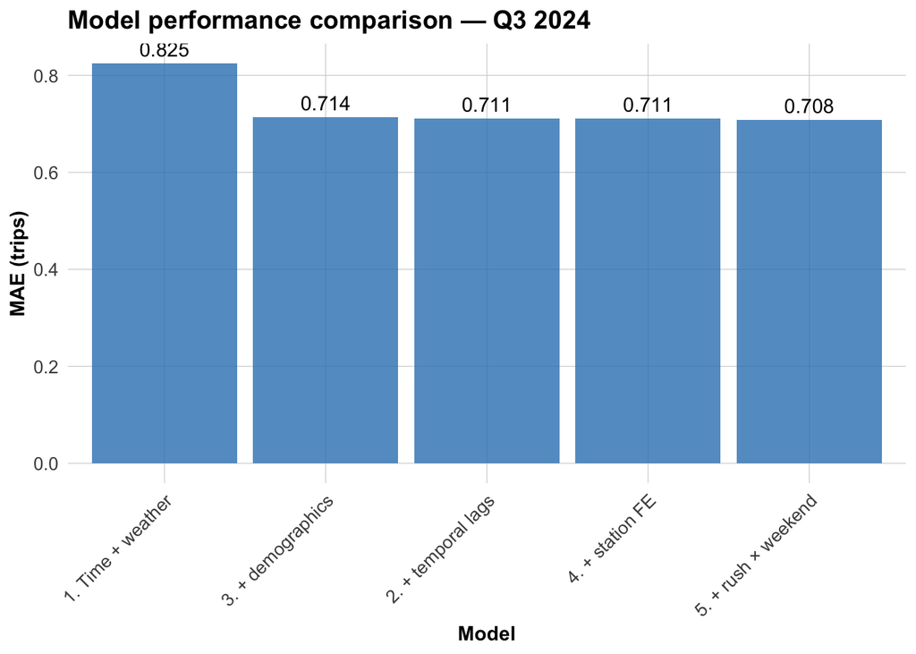

```r
ggplot(mae_baseline, aes(x = reorder(Model, -MAE), y = MAE)) +
  geom_col(fill = "#3182bd", alpha = 0.8) +
  geom_text(aes(label = round(MAE, 3)), vjust = -0.5) +
  labs(title = "Model performance comparison — Q3 2024",
       x = "Model", y = "MAE (trips)") +
  plotTheme +
  theme(axis.text.x = element_text(angle = 45, hjust = 1))
```

# Space-time error analysis (Model 5)

## Observed vs. predicted

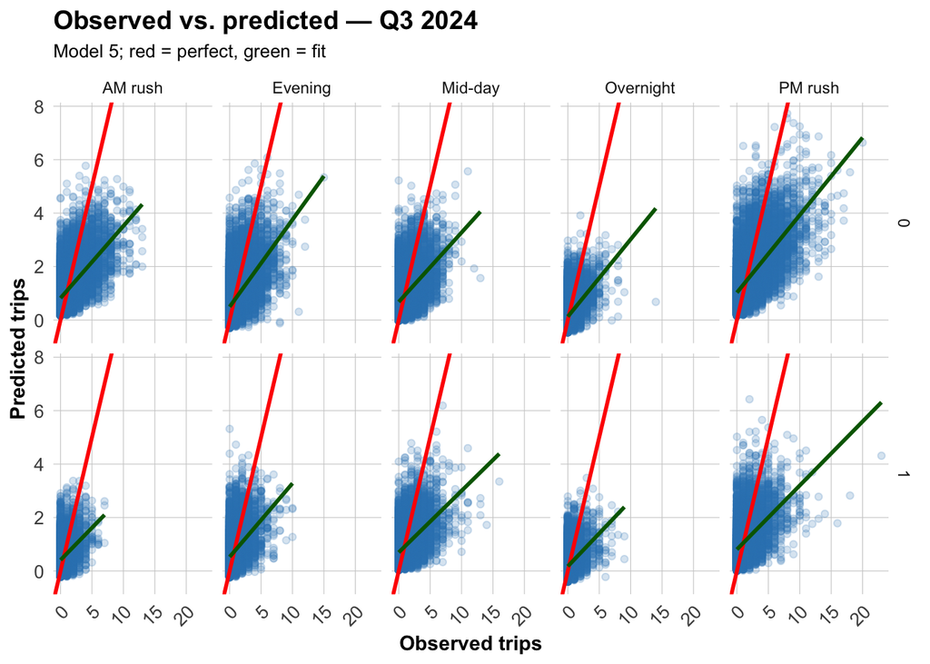

```r
test <- test %>%
  mutate(
    error       = Trip_Count - pred5,
    abs_error   = abs(error),
    time_of_day = case_when(
      hour <  7                ~ "Overnight",
      hour >= 7  & hour < 10   ~ "AM rush",
      hour >= 10 & hour < 15   ~ "Mid-day",
      hour >= 15 & hour <= 18  ~ "PM rush",
      hour >  18               ~ "Evening"
    )
  )

ggplot(test, aes(x = Trip_Count, y = pred5)) +
  geom_point(alpha = 0.2, color = "#3182bd") +
  geom_abline(slope = 1, intercept = 0, color = "red", linewidth = 1) +
  geom_smooth(method = "lm", se = FALSE, color = "darkgreen") +
  facet_grid(weekend ~ time_of_day) +
  labs(title = "Observed vs. predicted — Q3 2024",
       subtitle = "Model 5; red = perfect, green = fit",
       x = "Observed trips", y = "Predicted trips") +
  plotTheme
```

The standard pattern for OLS on counts with many zeros: predictions cluster near zero and the model under-predicts the high-demand tail. PM rush on weekdays is the worst-fitting cell.

## Spatial errors

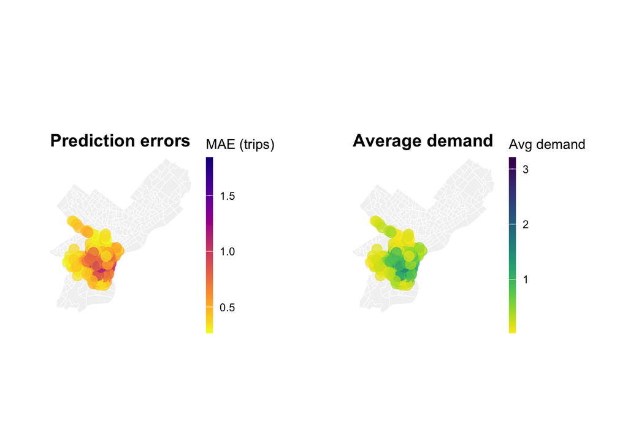

```r
station_errors <- test %>%
  filter(!is.na(pred5)) %>%
  group_by(start_station, start_lat, start_lon) %>%
  summarize(MAE        = mean(abs_error,  na.rm = TRUE),
            avg_demand = mean(Trip_Count, na.rm = TRUE),
            .groups    = "drop") %>%
  filter(!is.na(start_lat), !is.na(start_lon))

p1 <- ggplot() +
  geom_sf(data = philly_census, fill = "grey95", color = "white", size = 0.2) +
  geom_point(data = station_errors,
             aes(x = start_lon, y = start_lat, color = MAE),
             size = 3.5, alpha = 0.7) +
  scale_color_viridis(option = "plasma", name = "MAE (trips)", direction = -1) +
  labs(title = "Prediction errors") +
  mapTheme +
  theme(plot.title = element_text(hjust = 0.5))

p2 <- ggplot() +
  geom_sf(data = philly_census, fill = "grey95", color = "white", size = 0.2) +
  geom_point(data = station_errors,
             aes(x = start_lon, y = start_lat, color = avg_demand),
             size = 3.5, alpha = 0.7) +
  scale_color_viridis(option = "viridis", name = "Avg demand", direction = -1) +
  labs(title = "Average demand") +
  mapTheme +
  theme(plot.title = element_text(hjust = 0.5))

p1 | p2
```

Errors track demand. The high-MAE stations are the busy stations, Center City and the Schuylkill river path. An MAE of 1.0 trip on a station averaging 4 trips/hour is a 25% error; the same MAE on a quiet station averaging 0.3 trips/hour is a 333% error. The absolute-MAE map cannot distinguish them.

## Temporal errors

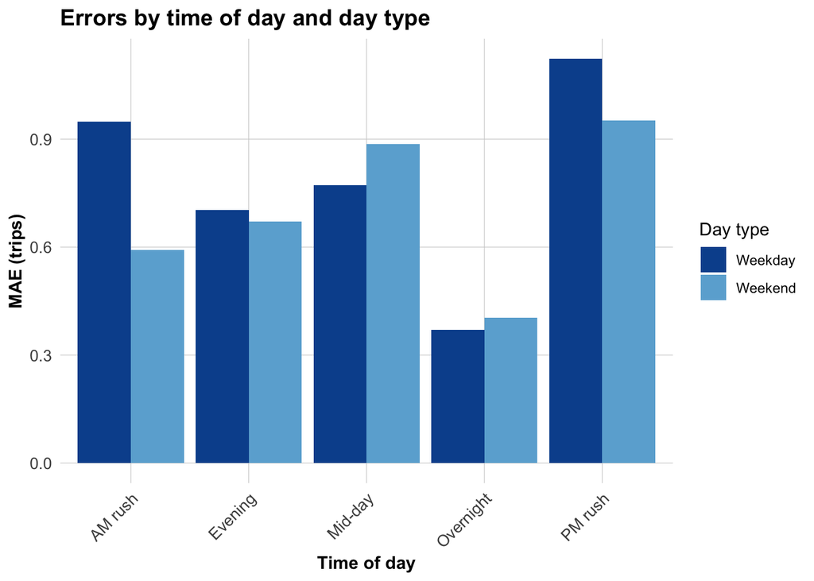

```r
temporal_errors <- test %>%
  group_by(time_of_day, weekend) %>%
  summarize(MAE = mean(abs_error, na.rm = TRUE), .groups = "drop") %>%
  mutate(day_type = ifelse(weekend == 1, "Weekend", "Weekday"))

ggplot(temporal_errors, aes(x = time_of_day, y = MAE, fill = day_type)) +
  geom_col(position = "dodge") +
  scale_fill_manual(values = c("Weekday" = "#08519c", "Weekend" = "#6baed6")) +
  labs(title = "Errors by time of day and day type",
       x = "Time of day", y = "MAE (trips)", fill = "Day type") +
  plotTheme +
  theme(axis.text.x = element_text(angle = 45, hjust = 1))
```

Weekday rush hours dominate the error budget, and PM rush is worse than AM rush. This is the operationally important window.

## Errors and demographics

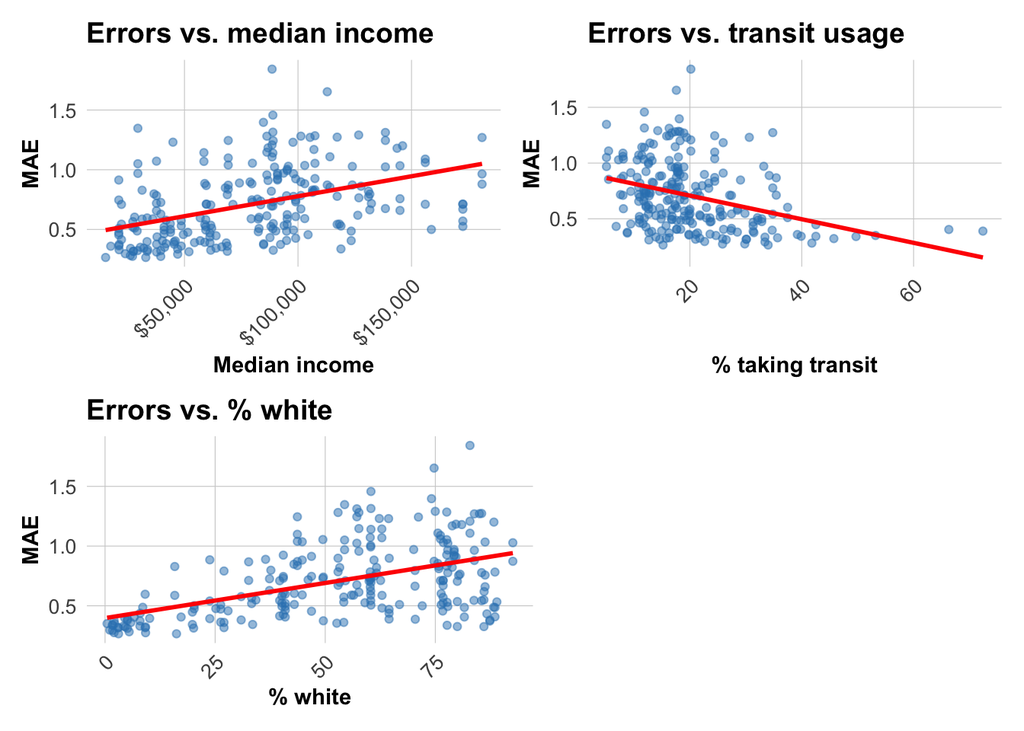

```r
station_errors_demo <- station_errors %>%
  left_join(station_attributes %>%
              select(start_station, Med_Inc,
                     Percent_Taking_Transit, Percent_White),
            by = "start_station") %>%
  filter(!is.na(Med_Inc))

p1 <- ggplot(station_errors_demo, aes(x = Med_Inc, y = MAE)) +
  geom_point(alpha = 0.5, color = "#3182bd") +
  geom_smooth(method = "lm", se = FALSE, color = "red") +
  scale_x_continuous(labels = scales::dollar) +
  labs(title = "Errors vs. median income",
       x = "Median income", y = "MAE") +
  plotTheme

p2 <- ggplot(station_errors_demo, aes(x = Percent_Taking_Transit, y = MAE)) +
  geom_point(alpha = 0.5, color = "#3182bd") +
  geom_smooth(method = "lm", se = FALSE, color = "red") +
  labs(title = "Errors vs. transit usage",
       x = "% taking transit", y = "MAE") +
  plotTheme

p3 <- ggplot(station_errors_demo, aes(x = Percent_White, y = MAE)) +
  geom_point(alpha = 0.5, color = "#3182bd") +
  geom_smooth(method = "lm", se = FALSE, color = "red") +
  labs(title = "Errors vs. % white",
       x = "% white", y = "MAE") +
  plotTheme

(p1 | p2) / (p3 | plot_spacer())
```

Errors are higher in wealthier and whiter tracts because that’s where the busiest stations are. This isn’t algorithmic bias against under-served communities in the conventional sense, but it has equity implications I return to in the reflection.

# Part 3 — feature engineering and improvements

The error analysis points at three failure modes:

1. Rush-hour under-prediction at high-demand stations.
2. Calendar anomalies the existing features can’t see 4 July, Labor Day, the late-August student return.
3. Spatial heterogeneity that station fixed effects absorb mechanically but don’t explain.

I add four features:

## Feature 1 — major holiday indicator

```r
us_holidays_q3 <- as.Date(c("2024-07-04", "2024-09-02"))  # July 4, Labor Day

study_panel_complete <- study_panel_complete %>%
  mutate(holiday = ifelse(date %in% us_holidays_q3, 1, 0))
```

## Feature 2 — university in session

Penn and Temple fall classes started 26 August 2024; Drexel later (23 September). A binary flag from 26 August captures the bulk of the regime change.

```r
fall_term_start <- as.Date("2024-08-26")
study_panel_complete <- study_panel_complete %>%
  mutate(uni_in_session = ifelse(date >= fall_term_start, 1, 0))
```

## Feature 3 — distance to City Hall

A continuous spatial gradient capturing the demand falloff from Center City. Largely co-linear with station fixed effects but useful in models without them.

```r
city_hall <- st_sfc(st_point(c(-75.1635, 39.9526)), crs = 4326)

stations_metric <- station_attributes %>%
  filter(!is.na(start_lat), !is.na(start_lon)) %>%
  st_as_sf(coords = c("start_lon", "start_lat"), crs = 4326) %>%
  st_transform(2272)  # PA South State Plane (feet)

city_hall_metric <- st_transform(city_hall, 2272)

stations_metric <- stations_metric %>%
  mutate(dist_city_hall_km =
           as.numeric(st_distance(., city_hall_metric)) * 0.0003048)

dist_lookup <- stations_metric %>%
  st_drop_geometry() %>%
  select(start_station, dist_city_hall_km)

study_panel_complete <- study_panel_complete %>%
  left_join(dist_lookup, by = "start_station")
```

## Feature 4 — rolling 7-day station mean

A station-level recent-demand level that updates through the quarter without leaking future information. Implemented as a 168-period lagged moving average via cumulative-sum differences.

```r
study_panel_complete <- study_panel_complete %>%
  arrange(start_station, interval60) %>%
  group_by(start_station) %>%
  mutate(
    cum_trips             = cumsum(replace_na(Trip_Count, 0)),
    cum_trips_lag168      = lag(cum_trips, 168),
    cum_trips_lag1        = lag(cum_trips, 1),
    rolling_7day_mean     = (cum_trips_lag1 - replace_na(cum_trips_lag168, 0)) /
                            pmin(row_number() - 1, 168)
  ) %>%
  ungroup() %>%
  mutate(rolling_7day_mean = replace_na(rolling_7day_mean, 0)) %>%
  select(-cum_trips, -cum_trips_lag168, -cum_trips_lag1)
```

## Refit the train/test split with new features

```r
train <- study_panel_complete %>%
  filter(week <  cutoff_week) %>%
  mutate(dotw_simple = factor(dotw,
           levels = c("Mon","Tue","Wed","Thu","Fri","Sat","Sun")))
contrasts(train$dotw_simple) <- contr.treatment(7)

test  <- study_panel_complete %>%
  filter(week >= cutoff_week) %>%
  mutate(dotw_simple = factor(dotw,
           levels = c("Mon","Tue","Wed","Thu","Fri","Sat","Sun")))
contrasts(test$dotw_simple) <- contr.treatment(7)
```

## Model 6 — Model 5 plus all four new features

```r
model6 <- lm(
  Trip_Count ~ as.factor(hour) + dotw_simple + Temperature + Precipitation +
    lag1Hour + lag3Hours + lag1day + rush_hour +
    Med_Inc + Percent_Taking_Transit + Percent_White +
    as.factor(start_station) +
    rush_hour * weekend +
    holiday + uni_in_session + dist_city_hall_km + rolling_7day_mean,
  data = train
)
cat("Model 6  R²:", summary(model6)$r.squared,
    " Adj R²:", summary(model6)$adj.r.squared, "\n")
```

```
Model 6  R²: 0.3469279  Adj R²: 0.3463542
```

```r
summary(model6)
```

```
Call:
lm(formula = Trip_Count ~ as.factor(hour) + dotw_simple + Temperature +
    Precipitation + lag1Hour + lag3Hours + lag1day + rush_hour +
    Med_Inc + Percent_Taking_Transit + Percent_White + as.factor(start_station) +
    rush_hour * weekend + holiday + uni_in_session + dist_city_hall_km +
    rolling_7day_mean, data = train)

Residuals:
    Min      1Q  Median      3Q     Max
-5.9186 -0.5514 -0.1370  0.2945 21.5277

Coefficients: (7 not defined because of singularities)
                                 Estimate   Std. Error t value
(Intercept)                  -0.721746677  0.101081234  -7.140
as.factor(hour)1             -0.050105231  0.013097943  -3.825
as.factor(hour)2             -0.051200493  0.013197153  -3.880
as.factor(hour)3             -0.081768271  0.013241134  -6.175
as.factor(hour)4             -0.055923284  0.013285098  -4.209
as.factor(hour)5              0.048482621  0.013314041   3.641
as.factor(hour)6              0.244970659  0.013377503  18.312
as.factor(hour)7              0.556598891  0.013727529  40.546
as.factor(hour)8              0.815749269  0.013765960  59.258
as.factor(hour)9              0.541892078  0.013778291  39.329
as.factor(hour)10             0.351291251  0.013349430  26.315
as.factor(hour)11             0.371858289  0.013280833  28.000
as.factor(hour)12             0.464090720  0.013188167  35.190
as.factor(hour)13             0.468153895  0.013155968  35.585
as.factor(hour)14             0.491763781  0.013167533  37.347
as.factor(hour)15             0.548574320  0.013214033  41.515
as.factor(hour)16             0.820595698  0.013624365  60.230
as.factor(hour)17             1.071542227  0.013819922  77.536
as.factor(hour)18             0.783082856  0.013827934  56.631
as.factor(hour)19             0.529619447  0.013427018  39.444
as.factor(hour)20             0.334887247  0.013391500  25.007
as.factor(hour)21             0.219303094  0.013267674  16.529
as.factor(hour)22             0.189542102  0.013187182  14.373
as.factor(hour)23             0.088747818  0.013108203   6.770
dotw_simple2                  0.031872659  0.007276890   4.380
dotw_simple3                  0.025759476  0.007335601   3.512
dotw_simple4                  0.008775410  0.007548986   1.162
```

[output cut: 523 more lines]

```
as.factor(start_station)3388                   NA
as.factor(start_station)3390                   NA
as.factor(start_station)3392                   NA
weekend                                        NA
holiday                      0.000000001430297494 ***
uni_in_session                                 NA
dist_city_hall_km                              NA
rolling_7day_mean            0.000000000000890771 ***
rush_hour:weekend            < 0.0000000000000002 ***
---
Signif. codes:  0 '***' 0.001 '**' 0.01 '*' 0.05 '.' 0.1 ' ' 1

Residual standard error: 1.052 on 308518 degrees of freedom
Multiple R-squared:  0.3469,    Adjusted R-squared:  0.3464
F-statistic: 604.8 on 271 and 308518 DF,  p-value: < 0.00000000000000022
```

## Model 7 — Poisson GLM

Trip counts are non-negative integers with many zeros and a long right tail, the case Poisson is designed for. The log link guarantees non-negative predictions, which OLS cannot.

```r
model7 <- glm(
  Trip_Count ~ as.factor(hour) + dotw_simple + Temperature + Precipitation +
    lag1Hour + lag3Hours + lag1day + rush_hour +
    Med_Inc + Percent_Taking_Transit + Percent_White +
    as.factor(start_station) +
    rush_hour * weekend +
    holiday + uni_in_session + dist_city_hall_km + rolling_7day_mean,
  data   = train,
  family = poisson(link = "log")
)

ll_model    <- as.numeric(logLik(model7))
ll_null     <- as.numeric(logLik(update(model7, . ~ 1)))
mcfadden_r2 <- 1 - ll_model / ll_null
cat("Model 7 (Poisson)  McFadden pseudo-R²:", round(mcfadden_r2, 4), "\n")
```

```
Model 7 (Poisson)  McFadden pseudo-R²: 0.2767
```

## Compare all seven on the test set

```r
test <- test %>%
  mutate(
    pred1 = predict(model1, newdata = test),
    pred2 = predict(model2, newdata = test),
    pred3 = predict(model3, newdata = test),
    pred4 = predict(model4, newdata = test),
    pred5 = predict(model5, newdata = test),
    pred6 = predict(model6, newdata = test),
    pred7 = predict(model7, newdata = test, type = "response")
  )

mae_full <- data.frame(
  Model = c("1. Time + weather",
            "2. + temporal lags",
            "3. + demographics",
            "4. + station FE",
            "5. + rush × weekend",
            "6. + new features (OLS)",
            "7. + new features (Poisson)"),
  MAE   = c(
    mean(abs(test$Trip_Count - test$pred1), na.rm = TRUE),
    mean(abs(test$Trip_Count - test$pred2), na.rm = TRUE),
    mean(abs(test$Trip_Count - test$pred3), na.rm = TRUE),
    mean(abs(test$Trip_Count - test$pred4), na.rm = TRUE),
    mean(abs(test$Trip_Count - test$pred5), na.rm = TRUE),
    mean(abs(test$Trip_Count - test$pred6), na.rm = TRUE),
    mean(abs(test$Trip_Count - test$pred7), na.rm = TRUE)
  )
)

kable(mae_full, digits = 3,
      caption = "MAE by model — Q3 2024 test set, all seven models",
      col.names = c("Model", "MAE (trips)")) %>%
  kable_styling(bootstrap_options = c("striped", "hover"))
```

MAE by model — Q3 2024 test set, all seven models

| Model | MAE (trips) |
| --- | --- |
| 1. Time + weather | 0.825 |
| 2. + temporal lags | 0.711 |
| 3. + demographics | 0.714 |
| 4. + station FE | 0.711 |
| 5. + rush × weekend | 0.708 |
| 6. + new features (OLS) | 0.707 |
| 7. + new features (Poisson) | 0.662 |

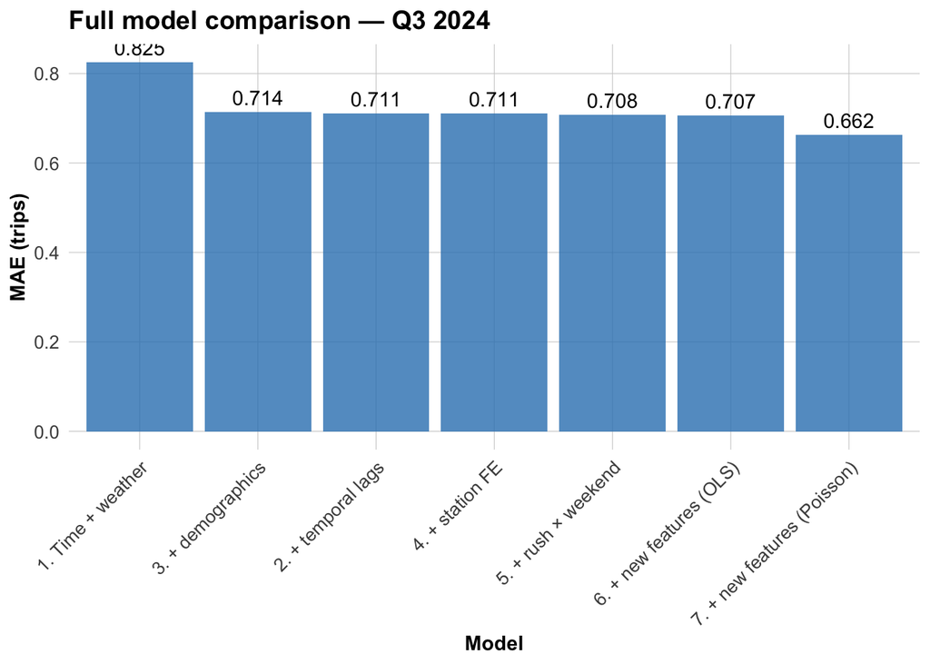

```r
ggplot(mae_full, aes(x = reorder(Model, -MAE), y = MAE)) +
  geom_col(fill = "#3182bd", alpha = 0.8) +
  geom_text(aes(label = round(MAE, 3)), vjust = -0.5) +
  labs(title = "Full model comparison — Q3 2024",
       x = "Model", y = "MAE (trips)") +
  plotTheme +
  theme(axis.text.x = element_text(angle = 45, hjust = 1))
```

## Where did the new features help?

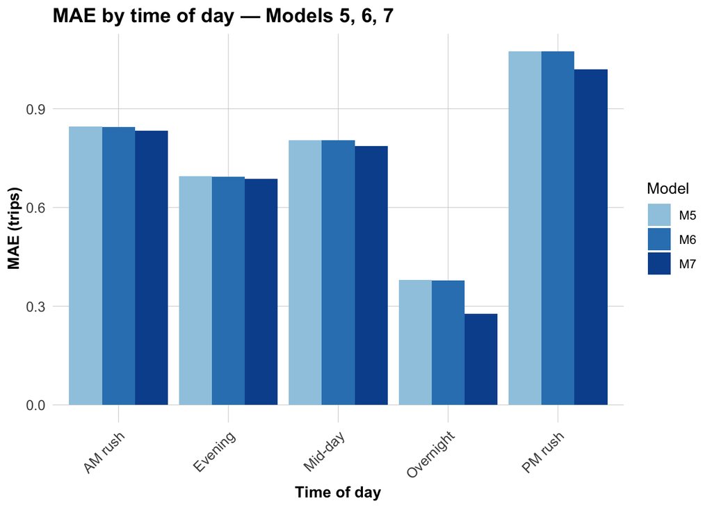

```r
test_long <- test %>%
  mutate(err_m5 = abs(Trip_Count - pred5),
         err_m6 = abs(Trip_Count - pred6),
         err_m7 = abs(Trip_Count - pred7),
         time_of_day = case_when(
           hour <  7                ~ "Overnight",
           hour >= 7  & hour < 10   ~ "AM rush",
           hour >= 10 & hour < 15   ~ "Mid-day",
           hour >= 15 & hour <= 18  ~ "PM rush",
           hour >  18               ~ "Evening"
         )) %>%
  group_by(time_of_day) %>%
  summarize(M5 = mean(err_m5, na.rm = TRUE),
            M6 = mean(err_m6, na.rm = TRUE),
            M7 = mean(err_m7, na.rm = TRUE),
            .groups = "drop") %>%
  pivot_longer(c(M5, M6, M7), names_to = "model", values_to = "MAE")

ggplot(test_long, aes(x = time_of_day, y = MAE, fill = model)) +
  geom_col(position = "dodge") +
  scale_fill_manual(values = c(M5 = "#9ecae1", M6 = "#3182bd", M7 = "#08519c")) +
  labs(title = "MAE by time of day — Models 5, 6, 7",
       x = "Time of day", y = "MAE (trips)", fill = "Model") +
  plotTheme +
  theme(axis.text.x = element_text(angle = 45, hjust = 1))
```

The four new features barely move overall MAE, Model 6 sits at 0.707 versus Model 5 at 0.708. The Poisson switch in Model 7 is the only meaningful gain after the initial lag step, dropping MAE to 0.662. This is a functional-form story, not a feature story: trip counts are counts, OLS is the wrong tool, and Poisson handles the mass at zero and the long tail correctly.

# Brief report

## Quarter and rationale

I chose Q3 2024 because summer is when Indego operates under most stress: highest ridership, tightest rebalancing constraints, and the largest cost of getting predictions wrong. The quarter also contains a real regime change, the late-August student return, which the in-class winter quarter could not see.

## Model comparison

The four new features in Model 6 reduce MAE by 0.001. The honest reading is that they didn’t help. Switching to Poisson in Model 7 takes MAE from 0.707 to 0.662, bigger than every single feature addition after Model 2. Poisson is doing this by getting the functional form right, not by extracting new signal.

## Error analysis

Three findings. First, errors track demand spatially. the worst-predicted stations are the busiest, in Center City and along the Schuylkill. This is partly mechanical (more trips means more variance to be wrong about) but it also tells us the model is missing structure that would help at high-volume stations specifically. Second, errors track demand temporally: PM rush on weekdays is the worst-fitting cell, which is exactly when rebalancing trucks have the least slack. Third, errors are higher in wealthier and whiter tracts because the busy stations are there. The model isn’t biased against under-served neighbourhoods in the conventional sense; it formalises the existing demand gradient.

## New features and why

Four features, motivated by the failure modes above. **Holiday flag** (4 July, Labor Day) for known calendar anomalies. **University in session** (≥ 26 August) for the late-August demand jump in University City and around Temple. **Distance to City Hall** for a continuous spatial gradient that station fixed effects absorb mechanically without explaining. **Rolling 7-day station mean** for a station-level recent-demand level that updates through the quarter.

## Critical reflection on deployment

Whether MAE 0.662 is good enough depends on the station and the decision. The mean trip count per station-hour in this test set sits below 1, most station-hours have 0 or 1 trips, so an MAE of 0.66 is comparable to typical demand at the median station. At a busy Center City station averaging 4 trips/hour, the same MAE is a 16% error, which is well within what truck-based rebalancing can absorb. At a quiet outer-Philadelphia station averaging 0.3 trips/hour, the same MAE is a 220% error and the model is worse than guessing the mean. The headline number hides this. I would deploy the model only for high-volume stations, with a fallback to a historical-average baseline at low-volume ones, and I would report predictions as ranges rather than as single numbers.

Errors are higher in Center City than in West, North, or South Philadelphia, but average demand is higher there too. If Indego rebalances proactively in proportion to predicted demand, the wealthier high-demand stations get more truck-time, which is what already happens. The safeguard worth flagging is monitoring relative error (MAE / average demand) by tract demographics rather than absolute error, so that systematically poor predictions in low-demand neighbourhoods aren’t masked by their small absolute size.